# projectfinish

Ricardo Andrés Rojas Rico & José Manuel Mendoza Vásquez

2023-06-08

# INTRODUCCIÓN

En este estudio, exploraremos la relación entre la altura y la edad en las personas. Utilizando técnicas estadísticas y probabilísticas, buscaremos predecir la altura en función de la edad y viceversa. Estos hallazgos nos permitirán obtener información valiosa sobre cómo la edad puede influir en la altura y viceversa. Este conocimiento puede tener aplicaciones prácticas en áreas como la medicina y la nutrición, así como en el desarrollo de modelos más precisos para estimar estas características físicas.

# Objetivo general:

- Analizar la relación entre la altura y la edad en las personas, utilizando técnicas estadísticas y probabilísticas, con el fin de predecir la altura en función de la edad y viceversa.

# Objetivos específicos:

1. Recolectar una muestra representativa de datos de altura y edad de personas de diferentes grupos de edad.
2. Aplicar técnicas estadísticas y modelos probabilísticos para analizar la correlación entre la altura y la edad.
3. Desarrollar un modelo predictivo que permita estimar la altura en base a la edad y viceversa, con un margen de error aceptable.

```r
file <- "C:/Users/rojas/OneDrive/Escritorio/proyectofinalR/db.txt"

datos <- read.table(file=file, header=TRUE)
# head(datos, n=18) # shows the first 6 rows

altura <- read.table(file=file, header = TRUE)
names(altura)
```

```
## [1] "edad"   "altura" "nota"
```

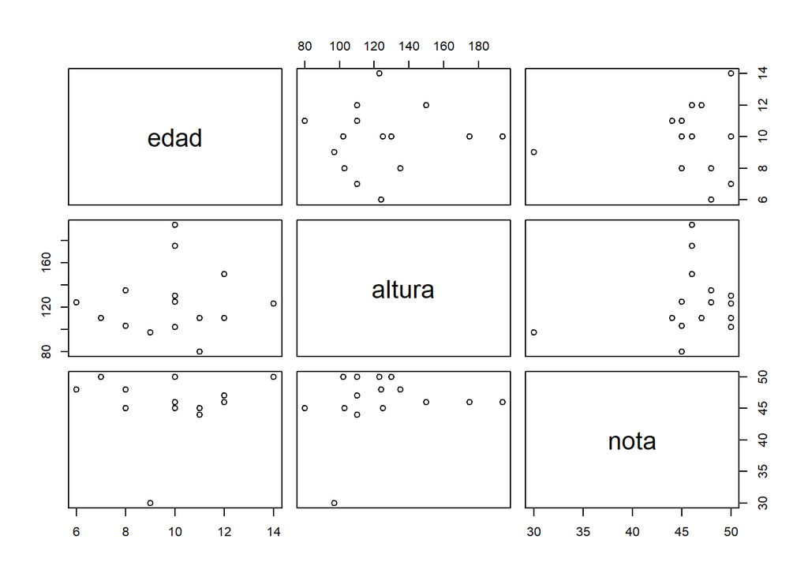

```r
pairs(altura)
```

```r
cor(altura)
```

```
##              edad     altura      nota
## edad   1.00000000 0.06023201 0.0635279
## altura 0.06023201 1.00000000 0.1990062
## nota   0.06352790 0.19900615 1.0000000
```

```r
regresion <- lm(edad ~ altura, data = datos)
summary(regresion)
```

```
##
## Call:
## lm(formula = edad ~ altura, data = datos)
##
## Residuals:
##     Min      1Q  Median      3Q     Max
## -3.8644 -1.2646  0.1106  1.2563  4.1397
##
## Coefficients:
##             Estimate Std. Error t value Pr(>|t|)
## (Intercept) 9.348347   2.445587   3.823  0.00211 **
## altura      0.004162   0.019130   0.218  0.83115
## ---
## Signif. codes:  0 '***' 0.001 '**' 0.01 '*' 0.05 '.' 0.1 ' ' 1
##
## Residual standard error: 2.14 on 13 degrees of freedom
## Multiple R-squared:  0.003628,   Adjusted R-squared:  -0.07302
## F-statistic: 0.04733 on 1 and 13 DF,  p-value: 0.8311
```

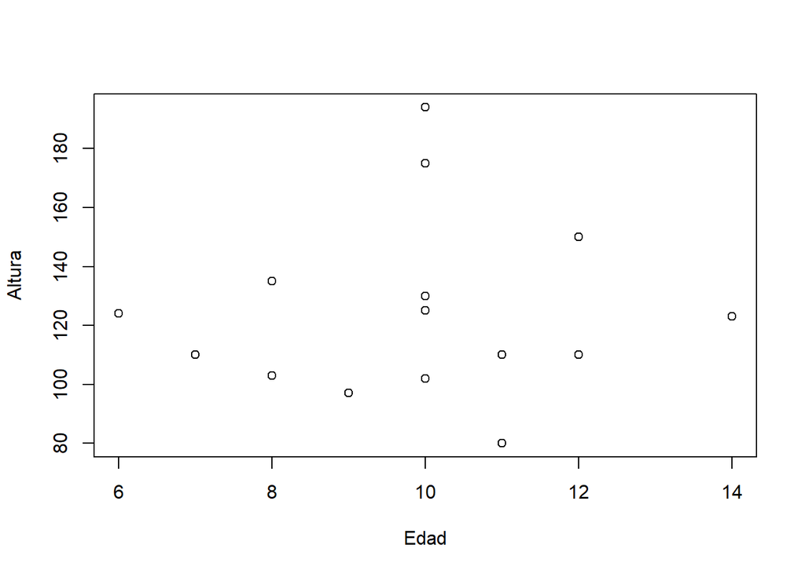

```r
plot(altura$edad, altura$altura, xlab='Edad', ylab='Altura')
abline(regresion)
```